# Let’s break some p-values

Steph and John

2019-03-17

# Intro banter

**John**: Where do you want to start Steph?

**Steph**: I don’t know John. How about we start with something that everyone reading this is probably familiar with? Did you want to do some $p$-value bashing?

**John**: Yeah, there are some Bayesians out there who refuse to do hypothesis testing on principal.

**John**: So what do you think

**John**: So a few years ago my wife was rear-ended while driving and the car was written off so we needed to buy a new car. While we were looking to get a new car my sister in law asked is (as a joke) “Are you getting a red car? I heard their fast!”

# Red cars are faster!

Let us imagine a simplified world. Suppose that

- There are only two car colours: **red** cars and **blue** cars.
- Cars can eiher be **sports** cars and **normal** cars.
- **Sports** cars are more likely to be **red** than **normal** cars
- **sports** cares are generally faster than **normal** cars.

## Directed acyclic graphs

Directed acyclic graphs can be used to capture the relationships between variables. In terms of a directed acyclic graph we have

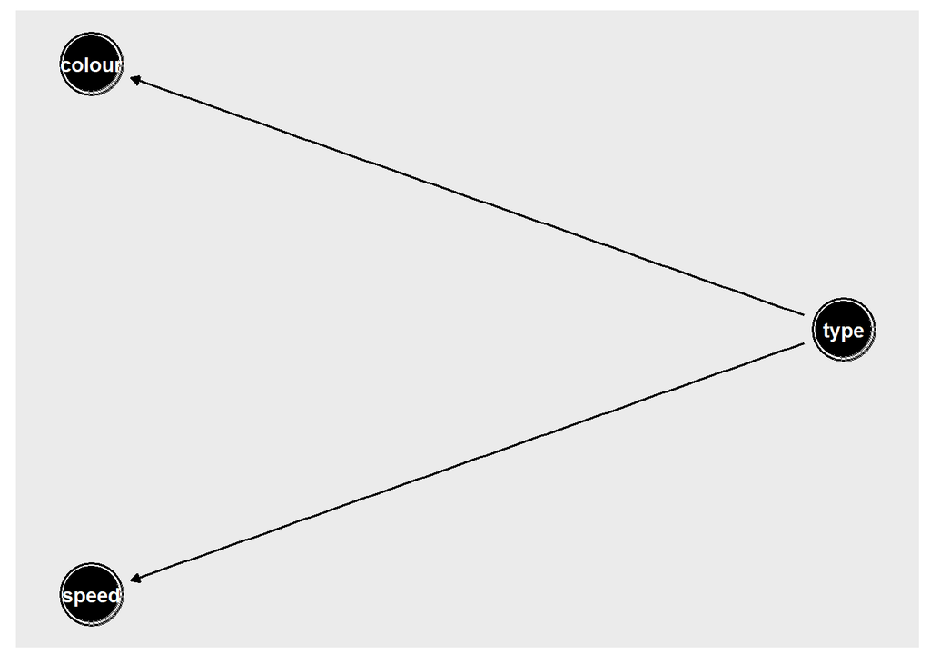

```r
# Using Malcolm Barrett's ggdag package
suppressPackageStartupMessages(library(dagitty))
suppressPackageStartupMessages(library(ggdag))

dagified <- dagify(colour ~ type,
                   speed ~ type,
                   exposure = "x",
                   outcome = "speed")
ggdag(dagified, layout = "circle")
```

There are three nodes type, colour and speed. The car type “causes” the car colour and the car speed so there are arrows from type to colour and speed.

## Simulating data

To put some probability structure on this let sports cars and normal cars be equally likely
$$\begin{array}{rl}
{\mathbb P}( \mbox{sports car} ) = 0.5 \\
{\mathbb P}( \mbox{normal car} ) = 0.5 \\
\end{array}$$
and
$$\begin{array}{rl}
{\mathbb P}( \mbox{red car} | \mbox{sports car} ) = 0.8 \\
{\mathbb P}( \mbox{blue car} | \mbox{sports car} ) = 0.2 \\
{\mathbb P}( \mbox{red car} | \mbox{normal car} ) = 0.2 \\
{\mathbb P}( \mbox{blue car} | \mbox{normal car} ) = 0.8 \\
\end{array}$$
Finally, suppose that the speed of the car is
$$\mbox{speed} = 100 + 50 \times {\mathbb I}(\mbox{sports car}) + N(0,50^2)$$

Lets simulate some data that captures this scenario.

```r
prob_sport <- 0.5
prob_red_given_sport  <- 0.8
prob_red_given_normal <- 0.2

mu_sport  <- 150
mu_normal <- 100
sd <- 50

n <- 100
type   <- rep(NA,n)
type_ind <- rbinom(n,1,prob_sport)
type[type_ind==1] <- "sport"
type[type_ind==0] <- "normal"
type <- as.factor(type)

nSport <- sum(type=="sport")
nNormal <- sum(type=="normal")

colour_ind <- rep(NA,n)
colour_ind[type=="sport"]  <- rbinom(nSport,1,prob_red_given_sport)
colour_ind[type=="normal"] <- rbinom(nNormal,1,prob_red_given_normal)

colour <- rep(NA,n)
colour[colour_ind==1] <- "red"
colour[colour_ind==0] <- "blue"
colour <- factor(colour,levels=c("red","blue"))

speed <-  mu_normal + (mu_sport - mu_normal)*(type=="sport") + rnorm(n,sd=50)

suppressPackageStartupMessages(library(tidyverse))

tib <- tibble(type=type,
              colour=colour,
              speed=speed)
```

So if we plot a boxplot for speed against colour we get.

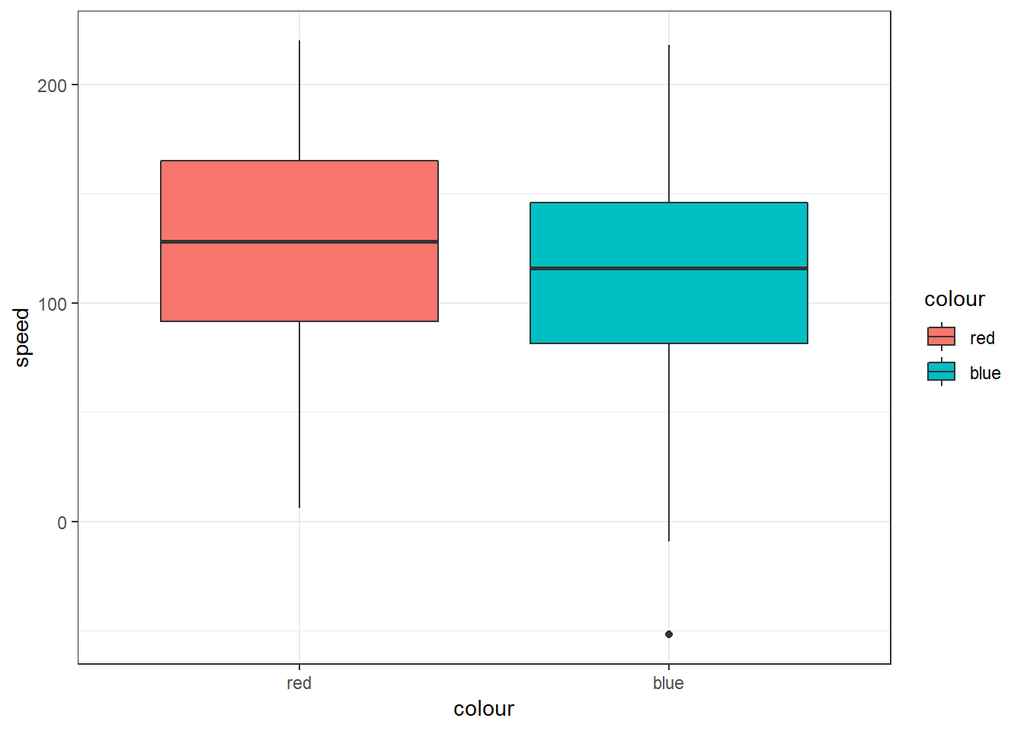

```r
p <- ggplot(tib, aes(x=colour, y=speed, fill=colour)) +
  geom_boxplot() +
  theme_bw()
p
```

## Boxplots

So if we plot a boxplot speed against type we get.

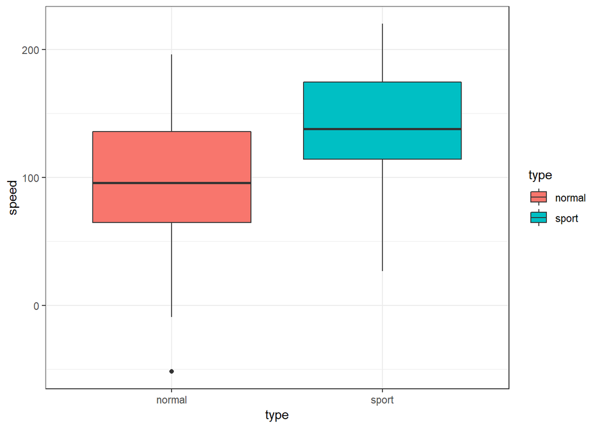

```r
p <- ggplot(tib, aes(x=type, y=speed,fill=type)) +
  geom_boxplot() +
  theme_bw()
p
```

## Two sample t-tests

So if we wanted to see if red cars were significantly faster than blue cars we could perform a $t$ test.

```r
# We use Lukas Burk, Tobias Anton, Daniel Lüdecke, and Gesa Graf's
#tadaatoolbox package to nicely summarise the results of a two sample t-test.
library(tadaatoolbox)

# Two sample t-test grouped using colour
tadaa_t.test(data = tib, response = speed, group = colour, print = "markdown")
```

Table 1: **Two Sample t-test** with alternative hypothesis: $\mu_1 \neq \mu_2$

| Diff | $\mu_1$ red | $\mu_2$ blue | t | SE | df | $CI_{95\%}$ | p | Cohen's d | Power |
| --- | --- | --- | --- | --- | --- | --- | --- | --- | --- |
| 15.05 | 126.56 | 111.51 | 1.41 | 10.64 | 98 | (-6.06 - 36.16) | 0.16 | 0.28 | 0.29 |

We could also do one where we group on type.

```r
# Two sample t-test grouped using type.
tadaa_t.test(data = tib, response = speed, group = type, print = "markdown")
```

Table 2: **Two Sample t-test** with alternative hypothesis: $\mu_1 \neq \mu_2$

| Diff | $\mu_1$ normal | $\mu_2$ sport | t | SE | df | $CI_{95\%}$ | p | Cohen's d | Power |
| --- | --- | --- | --- | --- | --- | --- | --- | --- | --- |
| -44.74 | 94.13 | 138.88 | -4.55 | 9.83 | 98 | (-64.25 - -25.23) | < 0.001 | -0.92 | 0.99 |

# Reproducibility, prediction and inference

Suppose that we went to a number of car yards where data was generated using the above process and we only observed

- the Speed of the car and the
- the Colour of the car.

Then

# Post example Banter

**John**: Ha ha that was so witty Steph.